# Google Data Analytics Certificarte Capstone

Ali Kaya

2022-12-11

## Scenario

You are a junior data analyst working in the marketing analyst team at Cyclistic, a bike-share company in Chicago. The director of marketing believes the company’s future success depends on maximizing the number of annual memberships. Therefore, your team wants to understand how casual riders and annual members use Cyclistic bikes differently. From these insights, your team will design a new marketing strategy to convert casual riders into annual members. But first, Cyclistic executives must approve your recommendations, so they must be backed up with compelling data insights and professional data visualizations.

## Characters and teams

- Cyclistic: A bike-share program that features more than 5,800 bicycles and 600 docking stations. Cyclistic sets itself apart by also offering reclining bikes, hand tricycles, and cargo bikes, making bike-share more inclusive to people with disabilities and riders who can’t use a standard two-wheeled bike. The majority of riders opt for traditional bikes; about 8% of riders use the assistive options. Cyclistic users are more likely to ride for leisure, but about 30% use them to commute to work each day.
- Lily Moreno: The director of marketing and your manager. Moreno is responsible for the development of campaigns and initiatives to promote the bike-share program. These may include email, social media, and other channels.
- Cyclistic marketing analytics team: A team of data analysts who are responsible for collecting, analyzing, and reporting data that helps guide Cyclistic marketing strategy. You joined this team six months ago and have been busy learning about Cyclistic’s mission and business goals — as well as how you, as a junior data analyst, can help Cyclistic achieve them.
- Cyclistic executive team: The notoriously detail-oriented executive team will decide whether to approve the recommended marketing program.

## About the Company

In 2016, Cyclistic launched a successful bike-share offering. Since then, the program has grown to a fleet of 5,824 bicycles that are geotracked and locked into a network of 692 stations across Chicago. The bikes can be unlocked from one station and returned to any other station in the system anytime.

Until now, Cyclistic’s marketing strategy relied on building general awareness and appealing to broad consumer segments. One approach that helped make these things possible was the flexibility of its pricing plans: single-ride passes, full-day passes, and annual memberships. Customers who purchase single-ride or full-day passes are referred to as casual riders. Customers who purchase annual memberships are Cyclistic members.

Cyclistic’s finance analysts have concluded that annual members are much more profitable than casual riders. Although the pricing flexibility helps Cyclistic attract more customers, Moreno believes that maximizing the number of annual members will be key to future growth. Rather than creating a marketing campaign that targets all-new customers, Moreno believes there is a very good chance to convert casual riders into members. She notes that casual riders are already aware of the Cyclistic program and have chosen Cyclistic for their mobility needs.

Moreno has set a clear goal: Design marketing strategies aimed at converting casual riders into annual members. In order to do that, however, *the marketing analyst team needs to better understand how annual members and casual riders differ*, why casual riders would buy a membership, and how digital media could affect their marketing tactics. Moreno and her team are interested in analyzing the Cyclistic historical bike trip data to identify trends.

## Roadmap for successful data analysis deliveries:

[output not shown]

### Ask: A clear statement of the business task

Based on the given context about this data-driven decision making project, we have to carefully think about business task before we proceed to any further steps. There is a hypothesis raised by the director of marketing, who believes “the company’s future success depends on maximizing the number of annual memberships”. Meanwhile, “the finance analysts have concluded that annual members are much more profitable than casual riders”.

Accordingluy, there are mainly two ways to expand the number of annual memberships, one is launching marketing campaigns that targets all-new customers, the other one is converting existing casual riders into annual members. After leveraging the pros and cons, costs and expectations, etc., the later one ‘should’ have a higher conversion rate with lower cost, as casual riders are already aware of the the program and have chosen it for their mobility needs.

Thus, in order to effectively convert the existing casual riders to annual members, it can be broken down into three main aspects:

1. Finding out differences: How do annual members and casual riders use Cyclistic bikes differently?
2. Knowing the reasoning for being an annual member: Why would casual riders buy Cyclistic annual memberships?
3. Setting up effective marketing approaches: How can Cyclistic use digital media to influence casual riders to become members?

We will see that this project is related to the `Question 1` due to dataset limitation mentioned in following “Prepare” step.

Before we go deeper on the dataset itself, general speaking, we should firstly think about in what ways we can differentiate between the two groups of users in the context of participating bike share programs. Here are some rough ideas/gut feelings:

1. Do casual riders use bicycles for a shorter period of time than the annual members on average?
2. Do casual riders use bicycles less frequently than annual members within a period of time on average?
3. Do casual riders use bicycles for a shorter distance than annual members on average?
4. Do annual members usually use bicycles for commuting(Peaking period from 7:00-9:00 A.M. and 17-19 P.M. per day)? More in summer than winter?
5. … …

> Ok, you might come up with more ideas. let’s leave them here and move on to the remaining phases to explore what we can do with the given dataset (Please keep in mind, in reality, theoretically we could do infinite analysis if we have ‘sufficient’ dataset. Even if we do not have ‘enough’ data metrics and dimensions till now, we can somehow try to collect them in the near future to continusly consolidate, update or even completely overturn the analytic results. All in all, data analysis is a process that requires long-term continuous revision)

### Prepare: A description of all data sources used

You can find data [here](https://divvy-tripdata.s3.amazonaws.com/index.html) (Note: The datasets have a different name because Cyclistic is a fictional company. For the purposes of this case study, the datasets are appropriate and will enable you to answer the business questions. The data has been made available by Motivate International Inc. under this [license](https://www.divvybikes.com/data-license-agreement).) This is public data that you can use to explore how different customer types are using Cyclistic bikes. But note that data-privacy issues prohibit you from using riders’ personally identifiable information. This means that you won’t be able to connect pass purchases to credit card numbers to determine if casual riders live in the Cyclistic service area or if they have purchased multiple single passes.

In prepare phase, we gonna focus on the dataset itself to adjust/refine/compromise/finalize our analytic goals(Or the ideas we mentioned in the ask phase). We should clarify the following aspects of the given data.

- Are there issues with bias or credibility in this data? Does your data ROCCC?
  - Reliable: accurate, complete and unbiased information that’s been vetted and proven fit for use – Lyft Bikes and Scooters, LLC (“Bikeshare”) operates the City of Chicago’s (“City”) Divvy bicycle sharing service. Bikeshare and the City are committed to supporting bicycling as an alternative transportation option. As part of that commitment, the City permits Bikeshare to make certain Divvy system data owned by the City (“Data”) available to the public.
  - Original: it is original and not collected through a second or third party source
  - Comprehensive: The best data sources contain all critical information needed to answer the question or find the solution – We will answer this question in the following quesion `Finally, how does it help you answer your question?`.
  - Current: Data is collected on a monthly basis. As of today, the latest dataset was collected in November 2022. In this analysis, we will be using data from December 2021 to November 2022.
  - Cited: Who created the data set? Is it part of a credible organization? When was the data last refreshed? – the City of Chicago permits Bikeshare to make certain Divvy system data owned by the City (“Data”) available to the public. It is refreshed on a monthly basis.
- How are you addressing licensing, privacy, security, and accessibility?
  - You can find the Data License Agreement [here](https://ride.divvybikes.com/data-license-agreement)
- How is the original data organized(structured)?

| Attribute | Type | Sample |
| --- | --- | --- |
| ride_id | String | 46F8167220E4431F |
| rideable_type | String | electric_bike |
| started_at | String | 2021-12-07 15:06:07 |
| ended_at | String | 2021-12-07 15:13:42 |
| start_station_name | String | Laflin St & Cullerton St |
| start_station_id | String | 13307 |
| end_station_name | String | Morgan St & Polk St |
| end_station_id | String | TA1307000130 |
| start_lat | Number | 41.85483 |
| start_lng | Number | -87.66366 |
| end_lat | Number | 41.87197 |
| end_lng | Number | 87.65097 |
| member_casual | String | member/casual |

- Finally, how does it help you answer your question?
  - the dataset contain 13 attributes, most indispensable attribute is the one named as ‘member_casual’, which can be used as a label to distinguish two groups of users
  - start and end time are recorded so that we can calculate the ride length (i.e., duration = ended_at - started_at)
  - start time can also be used to analyze the distribution per hour of using shared bikes.(Peaks and Troughs)
  - rideable_type can be used to analyze user preference between annual members and casual users
  - latitude and longitude can be used to calculate the distance per ride, and to draw corresponding routing on the map, which can be used to differentiate routing patterns between member and casual users
  - Time series data can also be used to analyze usage patterns in terms of day and night shifts, weekdays and weekends, season etc.

> The above-mentioned aspects will be the concrete analytic goals for this project. The detailed analysis processes and results will be given in the following sections.

### Process: Documentations of any cleaning or manipulation of data

#### Data was encapsulated in Zip format on a monthly basis. Thus, the data cleaning process will be applied to each month of data separately.

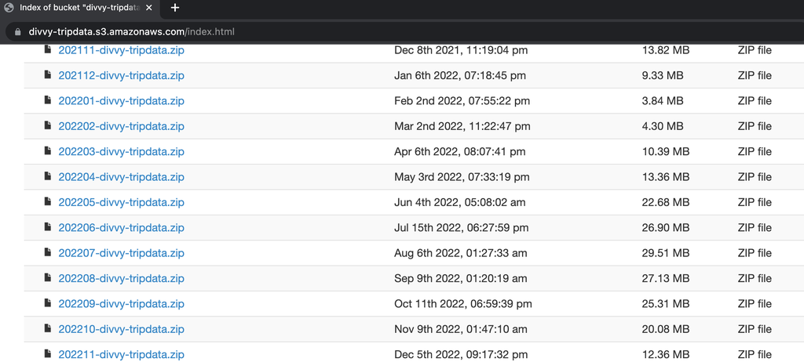

In order to ensure data’s integrity, we should consider the following aspects:

- Follow consistent file-naming conventions (if needed)
  - Since the data was well named by the provider, we don’t need to rename them.
- Remove invalid data (if any, e.g. NA, empty etc.)

```r
# import necessary libraries
library(tidyverse)
library(skimr)
library(hydroTSM)
library(geosphere)
library(dplyr)
library(psych)
library(lubridate)
```

```r
# Read the data from CSV to Data Frame
tripdata_202211 <- read.csv("./Case_Study_Bike_Sharing_Data/202211_tripdata.csv")
# skim_without_charts() is an alternative to summary(), quickly providing a broad overview of a data frame
tripdata_202211 %>% skim_without_charts()
```

Data summary

| Name | Piped data |
| --- | --- |
| Number of rows | 337735 |
| Number of columns | 13 |
| _______________________ |  |
| Column type frequency: |  |
| character | 9 |
| numeric | 4 |
| ________________________ |  |
| Group variables | None |

**Variable type: character**

| skim_variable | n_missing | complete_rate | min | max | empty | n_unique | whitespace |
| --- | --- | --- | --- | --- | --- | --- | --- |
| ride_id | 0 | 1 | 16 | 16 | 0 | 337735 | 0 |
| rideable_type | 0 | 1 | 11 | 13 | 0 | 3 | 0 |
| started_at | 0 | 1 | 19 | 19 | 0 | 300238 | 0 |
| ended_at | 0 | 1 | 19 | 19 | 0 | 300541 | 0 |
| start_station_name | 0 | 1 | 0 | 49 | 51957 | 1063 | 0 |
| start_station_id | 0 | 1 | 0 | 35 | 51957 | 1038 | 0 |
| end_station_name | 0 | 1 | 0 | 49 | 54259 | 1069 | 0 |
| end_station_id | 0 | 1 | 0 | 35 | 54259 | 1041 | 0 |
| member_casual | 0 | 1 | 6 | 6 | 0 | 2 | 0 |

**Variable type: numeric**

| skim_variable | n_missing | complete_rate | mean | sd | p0 | p25 | p50 | p75 | p100 |
| --- | --- | --- | --- | --- | --- | --- | --- | --- | --- |
| start_lat | 0 | 1 | 41.90 | 0.05 | 41.65 | 41.88 | 41.90 | 41.93 | 42.07 |
| start_lng | 0 | 1 | -87.65 | 0.03 | -87.84 | -87.66 | -87.64 | -87.63 | -87.52 |
| end_lat | 230 | 1 | 41.90 | 0.21 | 0.00 | 41.88 | 41.90 | 41.93 | 42.08 |
| end_lng | 230 | 1 | -87.65 | 0.43 | -87.84 | -87.66 | -87.65 | -87.63 | 0.00 |

```r
# Based on the output of skim_without_charts(), we should clean dataset based on the following criteria
# 1. search and delete empty rows with 'empty' tag on variables: start_station_name, start_station_id, end_station_name and end_station_id, respectively
# 2. search and delete NA rows with 'n_missing' tag on variables: end_lat and eng_lng, respectively
tripdata_202211 <- tripdata_202211 %>% filter(start_station_name != '', start_station_id !='', end_station_name != '', end_station_id !='') %>% filter(!is.na(end_lat), !is.na(end_lng))
```

- Remove inapplicable data (if any, e.g., started_at >= ended_at, this might be adjustable if we change their positions to each other. We don’t know whether this is caused by inapplicable transmission or other malfunctions, so we just simply remove them from dataset to achieve data integrity; Meanwhile, we suppose the ride_length(ended_at-started_at) should be larger than 60s. Otherwise, this is not an ‘effective riding’)

```r
# 1. search for and remove ineffective ride(ride_length < 60s)
cleaned_202211 <- tripdata_202211 %>% filter(difftime(ended_at, started_at, units="secs") >= 60)
```

- Create new variables to help on further analysis

```r
# 1. create a new variable which is named as ride_length(the duration per ride calculated based on started_at and ended_at), and filter out ride_length == 0
temp_202211 <- cleaned_202211 %>%  mutate(ride_length = difftime(ended_at, started_at, units="secs")) %>% transform(ride_length = as.numeric(ride_length)) %>% filter(ride_length != 0)

# 2. create a new variable which names as day_of_week(the day of the week per ride based on started_at and ended_at)
temp_202211 <- temp_202211 %>% mutate(day_of_week = '') %>% transform(day_of_week = weekdays(as.Date(started_at)))

# 3. create a new variable which names as season, indicating the season when using the bikes
temp_202211 <- temp_202211 %>% mutate(season = time2season(as.Date(started_at), out.fmt = "seasons"))

# 4. create a new variable which names as distance, indicating the distance per ride. Note using Interface Between R and Google Maps will need the API Key. In order to reduce the API cost, we choose another distance calculation package to calculate the Haversine distance instead.

prepared_202211 <- temp_202211 %>% mutate(distance = distHaversine(select(temp_202211, start_lng, start_lat), select(temp_202211, end_lng, end_lat)))
rm(temp_202211)
```

- Save cleaned data for further analysis

```r
write.csv(prepared_202211, file = paste('./Cleaned_Data/', deparse(substitute(prepared_202211)) ,'.csv', sep="") , fileEncoding = 'UTF-8', row.names = FALSE)
```

> Please keep in mind we have in total 12 months data needed to be cleaned and prepared. We do them separately and combine them together into one csv for analysis.

### Analyze: Supporting visualizations and key findings

#### Let’s load and have a look at the cleaned and prepared data (Suppose we did combine cleaned 12 months data into one prepared_all.csv. We could see after appropriate data cleaning and preparation, we totally have 4334101 records.)

```r
prepared_all <- read.csv("./Cleaned_Data/prepared_all.csv")
skim_without_charts(prepared_all)
```

Data summary

| Name | prepared_all |
| --- | --- |
| Number of rows | 4334101 |
| Number of columns | 17 |
| _______________________ |  |
| Column type frequency: |  |
| character | 11 |
| numeric | 6 |
| ________________________ |  |
| Group variables | None |

**Variable type: character**

| skim_variable | n_missing | complete_rate | min | max | empty | n_unique | whitespace |
| --- | --- | --- | --- | --- | --- | --- | --- |
| ride_id | 0 | 1 | 16 | 16 | 0 | 4334101 | 0 |
| rideable_type | 0 | 1 | 11 | 13 | 0 | 3 | 0 |
| started_at | 0 | 1 | 19 | 19 | 0 | 3761873 | 0 |
| ended_at | 0 | 1 | 19 | 19 | 0 | 3774490 | 0 |
| start_station_name | 0 | 1 | 7 | 64 | 0 | 1529 | 0 |
| start_station_id | 0 | 1 | 3 | 44 | 0 | 1259 | 0 |
| end_station_name | 0 | 1 | 10 | 64 | 0 | 1575 | 0 |
| end_station_id | 0 | 1 | 3 | 44 | 0 | 1273 | 0 |
| member_casual | 0 | 1 | 6 | 6 | 0 | 2 | 0 |
| day_of_week | 0 | 1 | 6 | 9 | 0 | 7 | 0 |
| season | 0 | 1 | 6 | 6 | 0 | 4 | 0 |

**Variable type: numeric**

| skim_variable | n_missing | complete_rate | mean | sd | p0 | p25 | p50 | p75 | p100 |
| --- | --- | --- | --- | --- | --- | --- | --- | --- | --- |
| start_lat | 0 | 1 | 41.90 | 0.04 | 41.65 | 41.88 | 41.90 | 41.93 | 45.64 |
| start_lng | 0 | 1 | -87.64 | 0.03 | -87.83 | -87.66 | -87.64 | -87.63 | -73.80 |
| end_lat | 0 | 1 | 41.90 | 0.07 | 0.00 | 41.88 | 41.90 | 41.93 | 42.06 |
| end_lng | 0 | 1 | -87.64 | 0.11 | -87.83 | -87.66 | -87.64 | -87.63 | 0.00 |
| ride_length | 0 | 1 | 1047.23 | 3270.56 | 60.00 | 376.00 | 649.00 | 1157.00 | 2061244.00 |
| distance | 0 | 1 | 2144.30 | 12633.13 | 0.00 | 914.03 | 1595.60 | 2773.13 | 9825063.44 |

#### We gonna analyze the following aspects to illustrate the differences between Casual and Member users.

- All year round data analysis:
  - Frequency of rides grouped by user type: casual or member

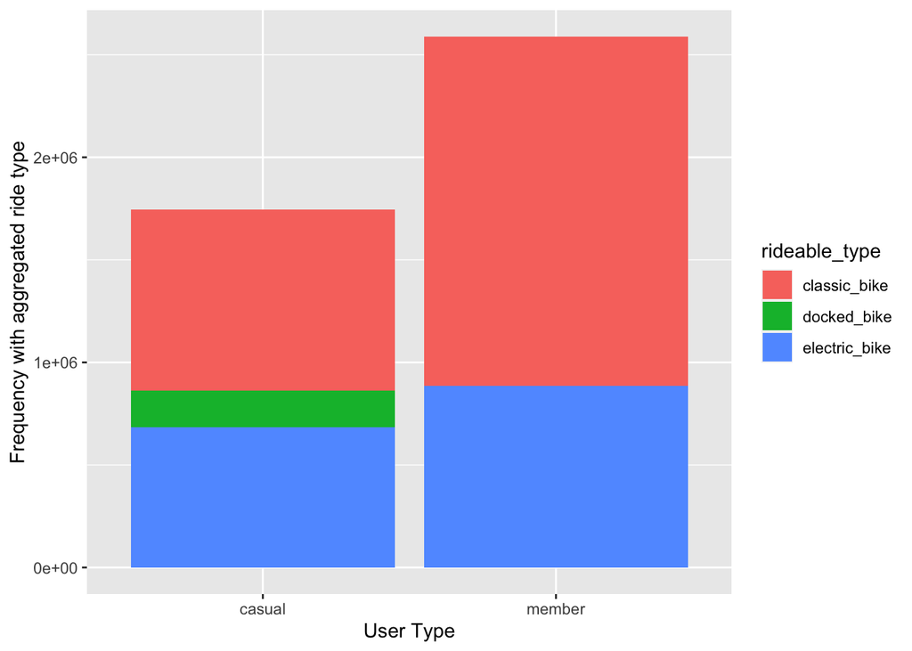

```r
prepared_all %>% ggplot(aes(x = member_casual, group = rideable_type, fill = rideable_type)) +
  geom_bar()+
  labs(x = "User Type",
       y = "Frequency with aggregated ride type")
```

- Average riding time(s) per ride grouped by user type: casual or member

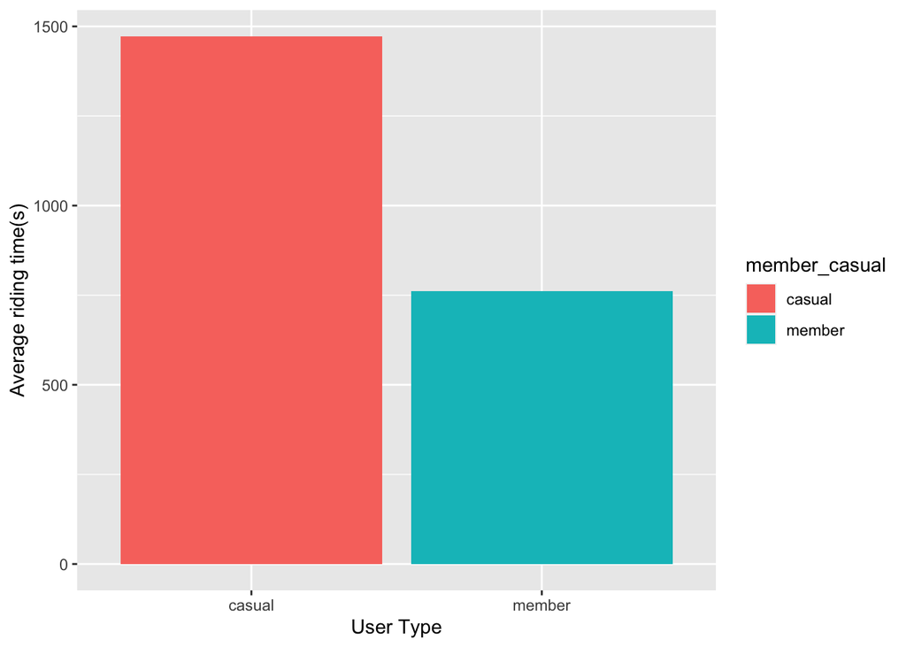

```r
prepared_all %>%
  group_by(member_casual) %>%
  summarize(mlen = mean(ride_length)) %>%
  ggplot(aes(x = member_casual, y = mlen, fill = member_casual)) +
  geom_bar(stat = 'identity') +
    labs(x = "User Type",
       y = "Average riding time(s)")
```

- Average riding distance(m) per ride grouped by user type: casual or member

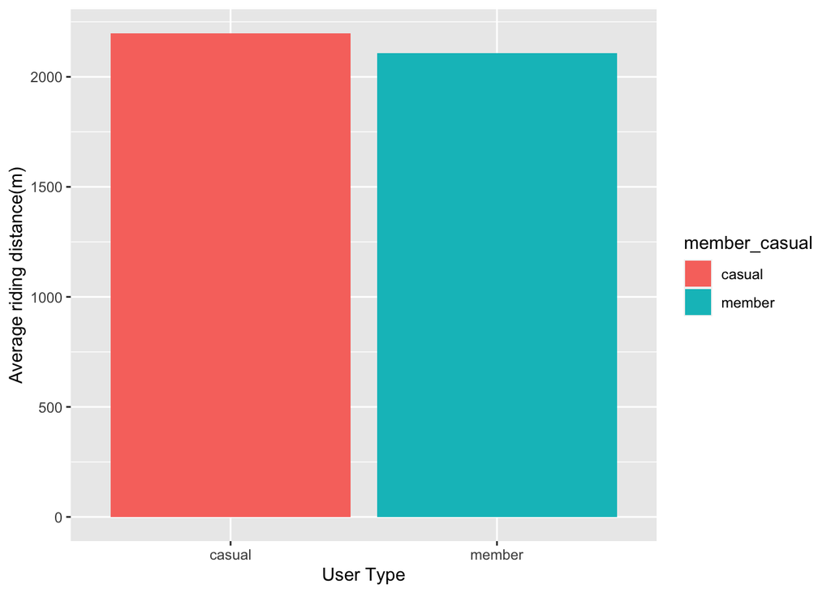

```r
prepared_all %>%
  group_by(member_casual) %>%
  summarize(mlen = mean(distance)) %>%
  ggplot(aes(x = member_casual, y = mlen, fill = member_casual)) +
  geom_bar(stat = 'identity')  +
    labs(x = "User Type",
       y = "Average riding distance(m)")
```

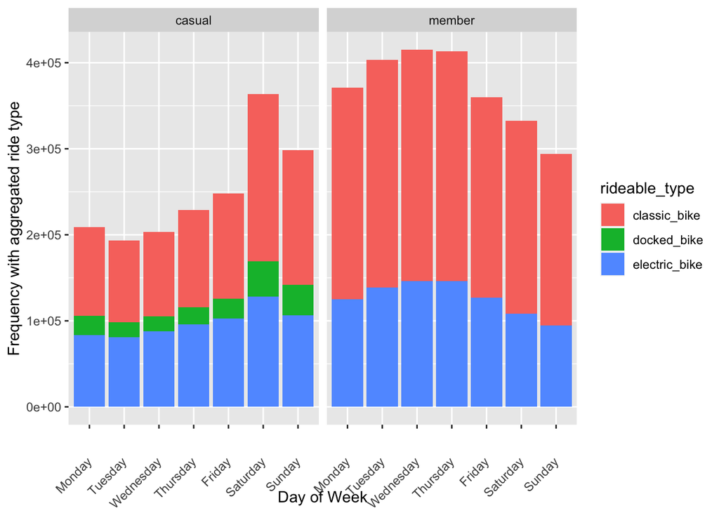

```r
options(dplyr.summarise.inform = FALSE)
# set up factor and level to plot bar from Monday to Sunday accordingly.
prepared_all$day_of_week <- factor(prepared_all$day_of_week, levels = c("Monday", "Tuesday", "Wednesday", "Thursday", "Friday", "Saturday", "Sunday"))
prepared_all %>% ggplot(aes(x = day_of_week, group = rideable_type, fill = rideable_type)) +
  geom_bar()+
  theme(axis.text.x = element_text(angle=45, vjust=.5, hjust=1))+
  facet_wrap(~member_casual)+
    labs(x = "Day of Week",
       y = "Frequency with aggregated ride type")
```

- Average riding time(s) per day of the week grouped by user type: casual or member

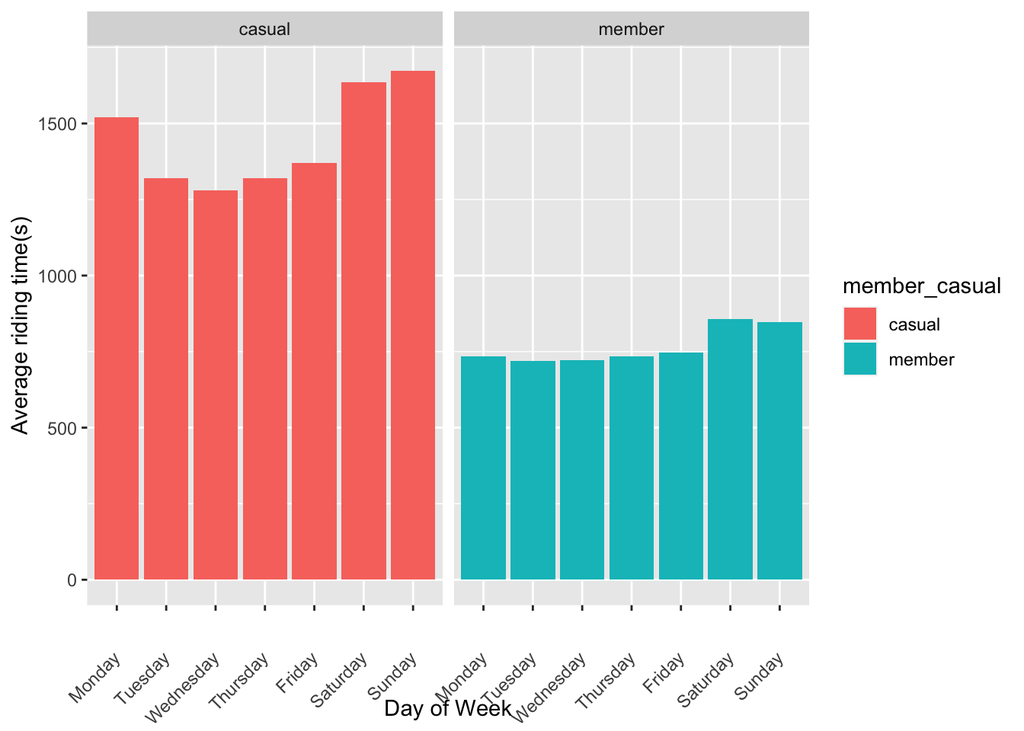

```r
temp <- prepared_all %>%
  group_by(day_of_week, member_casual) %>%
  summarize(mlen = mean(ride_length))
temp$day_of_week <- factor(temp$day_of_week, levels = c("Monday", "Tuesday", "Wednesday", "Thursday", "Friday", "Saturday", "Sunday"))
temp %>% ggplot(aes(x = day_of_week, y = mlen, fill = member_casual)) +
  geom_bar(stat = 'identity')+
  theme(axis.text.x = element_text(angle=45, vjust=.5, hjust=1))+
  facet_wrap(~member_casual)+
    labs(x = "Day of Week",
       y = "Average riding time(s)")
```

```r
rm(temp)
```

- Average riding distance(s) per day of the week grouped by user type: casual or member

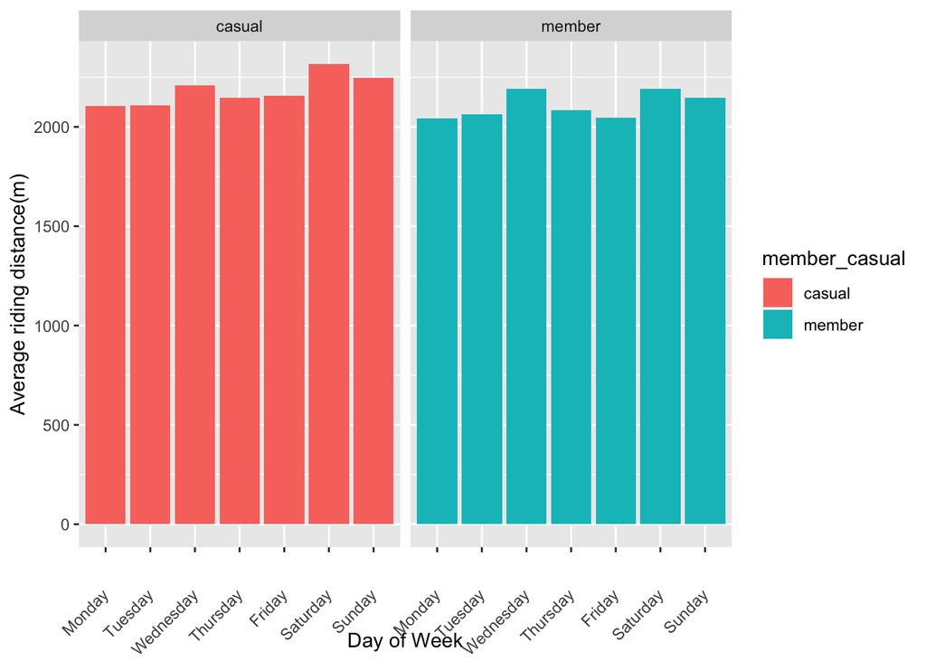

```r
temp <- prepared_all %>%
  group_by(day_of_week, member_casual) %>%
  summarize(mlen = mean(distance))
temp$day_of_week <- factor(temp$day_of_week, levels = c("Monday", "Tuesday", "Wednesday", "Thursday", "Friday", "Saturday", "Sunday"))
temp %>% ggplot(aes(x = day_of_week, y = mlen, fill = member_casual)) +
  geom_bar(stat = 'identity')+
  theme(axis.text.x = element_text(angle=45, vjust=.5, hjust=1))+
  facet_wrap(~member_casual)+
    labs(x = "Day of Week",
       y = "Average riding distance(m)")
```

```r
rm(temp)
```

> Finding 3: The frequency patterns of annual members and casual members per day of week through out the whole year are different. Casual members tend to use shared bicycles more frequently on weekends, while annual members use shared bicycles more frequently on weekdays.

> Finding 4: If we spread the average riding time per ride into the day of weeks, we can clearly find out casual members have a longer riding time per ride on weekends than they do on weekdays, while this difference is almost non-existent among annual members

> Finding 5: If we spread the average riding distance into the day of weeks, both casual users and annual members cycled slightly higher distances on Wednesdays and weekends than at other times
- Involving rideable type dimension to differentiate user behaviors: :
  - Frequency of rides per rideable type grouped by user type: casual or member

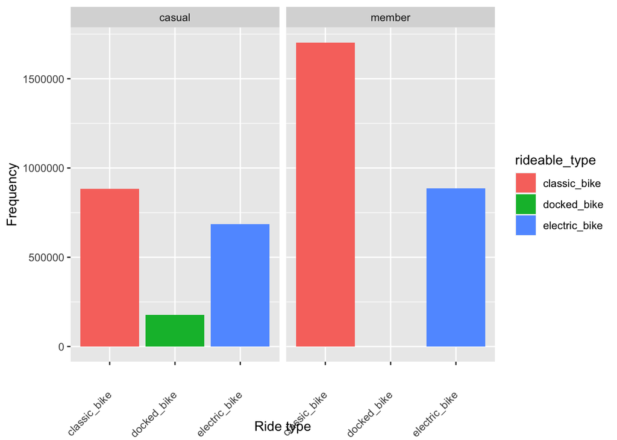

```r
options(dplyr.summarise.inform = FALSE)
prepared_all %>% ggplot(aes(x = rideable_type, group = rideable_type, fill = rideable_type)) +
  geom_bar()+
  theme(axis.text.x = element_text(angle=45, vjust=.5, hjust=1))+
  facet_wrap(~member_casual)+
    labs(x = "Ride type",
       y = "Frequency")
```

- Average riding time(s) per rideable_type grouped by user type: casual or member

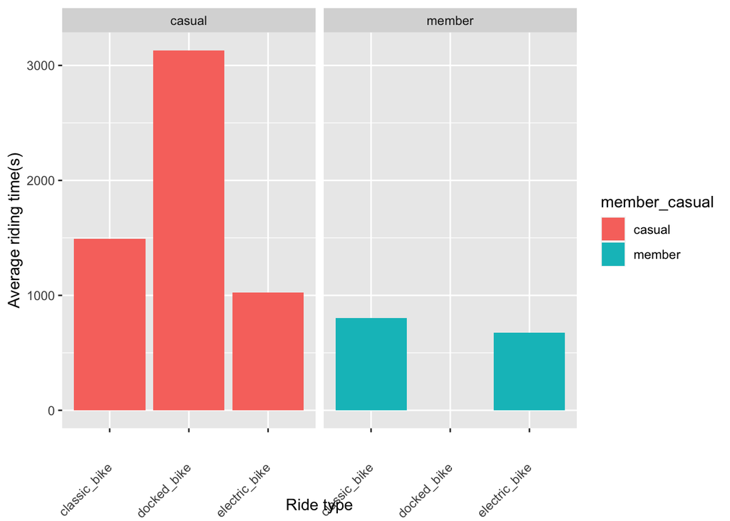

```r
prepared_all %>%
  group_by(rideable_type, member_casual) %>%
  summarize(mlen = mean(ride_length)) %>%
  ggplot(aes(x = rideable_type, y = mlen, fill = member_casual)) +
  geom_bar(stat = 'identity')+
  theme(axis.text.x = element_text(angle=45, vjust=.5, hjust=1))+
  facet_wrap(~member_casual)+
    labs(x = "Ride type",
       y = "Average riding time(s)")
```

- Average riding distance per rideable type grouped by user type: casual or member

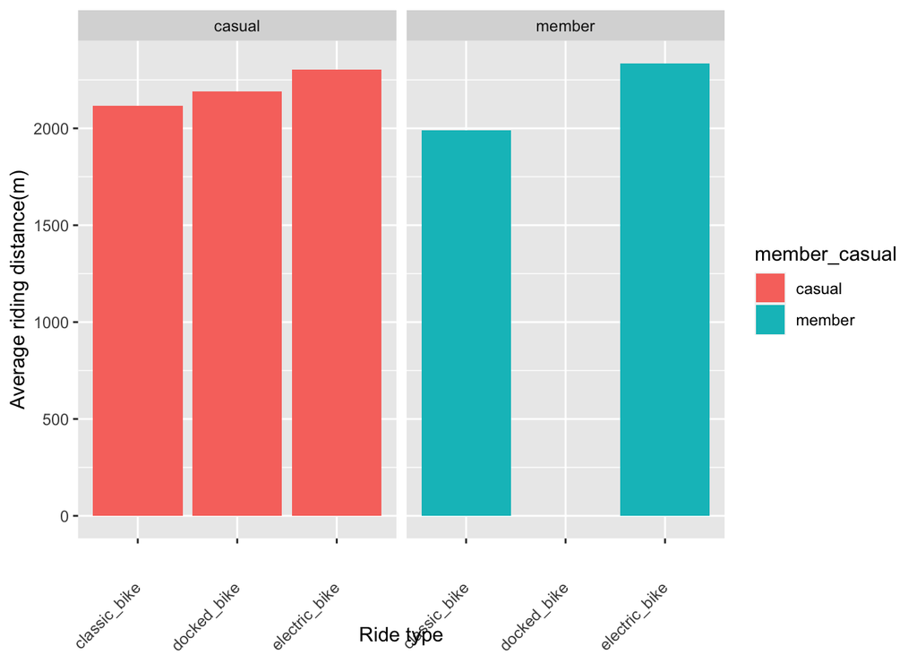

```r
prepared_all %>%
  group_by(rideable_type, member_casual) %>%
  summarize(mlen = mean(distance)) %>%
  ggplot(aes(x = rideable_type, y = mlen, fill = member_casual)) +
  geom_bar(stat = 'identity')+
  theme(axis.text.x = element_text(angle=45, vjust=.5, hjust=1))+
  facet_wrap(~member_casual)+
    labs(x = "Ride type",
       y = "Average riding distance(m)")
```

> Finding 6: All users (annual members more significant) are more inclined to use classic bikes, then electric bikes. Docked bikes are minimally used among casual users and never used among annual members.

> Finding 7: Surprisingly, the average riding time on an docked bike turns out to be the longest even though few casual users use it.

> Finding 8: The average riding distance of electric bikes is the highest one, but not noticeable among different bike types.
- Involving season dimension to differentiate user behaviors:
  - Frequency of rides per season grouped by user type: casual or member

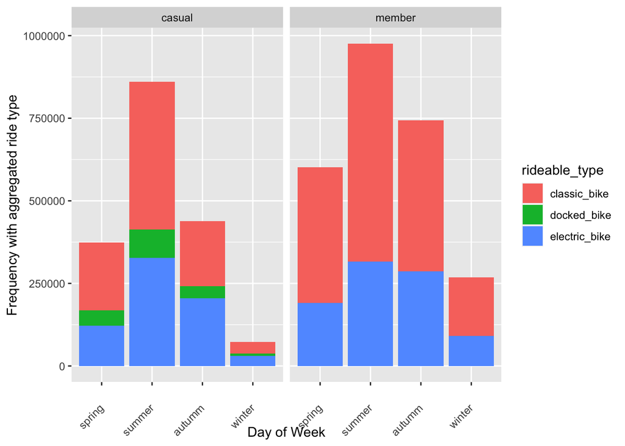

```r
# set up factor and level to plot bar from spring to winter accordingly.
prepared_all$season <- factor(prepared_all$season, levels = c("spring", "summer", "autumm", "winter"))
prepared_all %>% ggplot(aes(x = season, group = rideable_type, fill = rideable_type)) +
  geom_bar()+
  theme(axis.text.x = element_text(angle=45, vjust=.5, hjust=1))+
  facet_wrap(~member_casual)+
    labs(x = "Day of Week",
       y = "Frequency with aggregated ride type")
```

- Average riding time(s) per season grouped by user type: casual or member

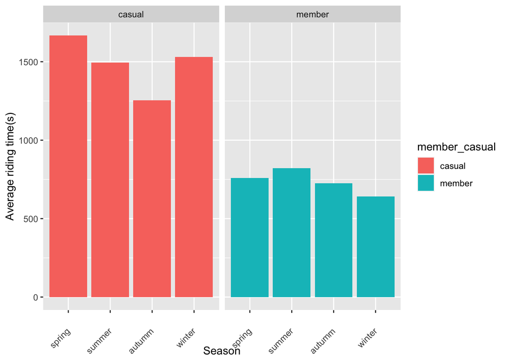

```r
options(dplyr.summarise.inform = FALSE)
temp <- prepared_all %>%
  group_by(season, member_casual) %>%
  summarize(mlen = mean(ride_length))
temp$season <- factor(temp$season, levels = c("spring", "summer", "autumm", "winter"))
temp %>% ggplot(aes(x = season, y = mlen, fill = member_casual)) +
  geom_bar(stat = 'identity')+
  theme(axis.text.x = element_text(angle=45, vjust=.5, hjust=1))+
  facet_wrap(~member_casual)+
    labs(x = "Season",
       y = "Average riding time(s)")
```

```r
rm(temp)
```

- Average riding distance per season grouped by user type: casual or member

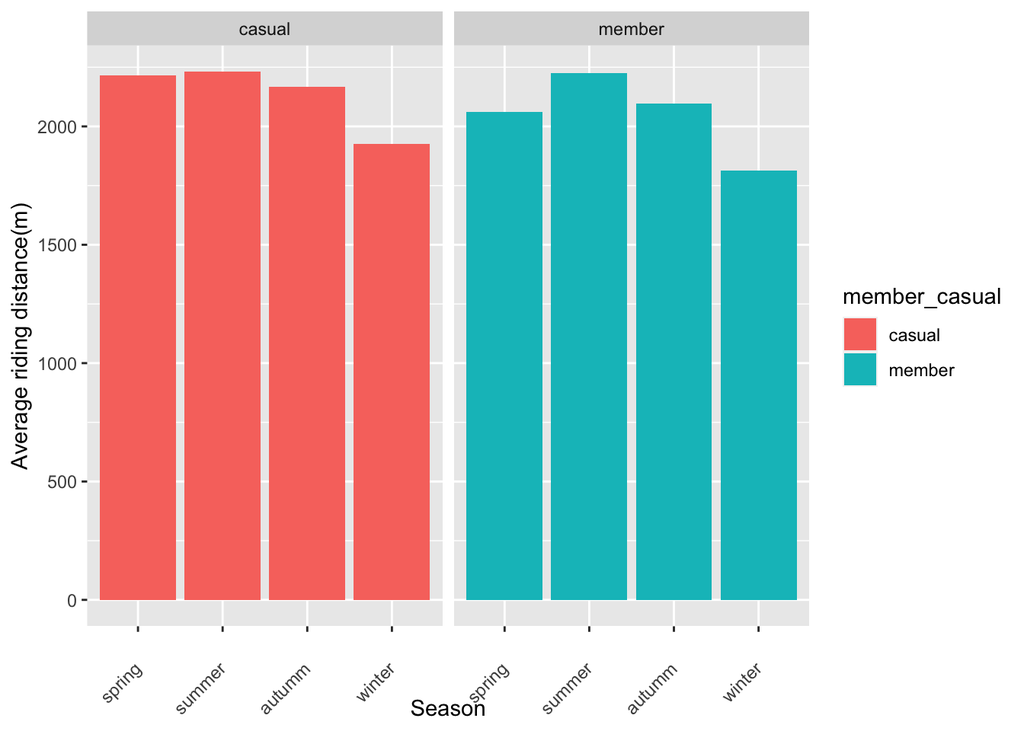

```r
options(dplyr.summarise.inform = FALSE)
temp <- prepared_all %>%
  group_by(season, member_casual) %>%
  summarize(mlen = mean(distance))
temp$season <- factor(temp$season, levels = c("spring", "summer", "autumm", "winter"))
temp %>% ggplot(aes(x = season, y = mlen, fill = member_casual)) +
  geom_bar(stat = 'identity')+
  theme(axis.text.x = element_text(angle=45, vjust=.5, hjust=1))+
  facet_wrap(~member_casual)+
    labs(x = "Season",
       y = "Average riding distance(m)")
```

```r
rm(temp)
```

> Finding 9: For all users, the seasons in which shared bikes are mainly used are summer and autumn

> Finding 10: Surprisingly, for casual users, although the frequency of using shared bikes is relatively high in summer and autumn, the average riding time(s) per use is shorter than in spring and winter. This pattern was not found in annual members

> Finding 11: In warm seasons, the average riding distance of shared bikes is generally higher than in cold seasons among all users
- Involving Hour dimension to differentiate user behaviors:
  - Frequency of rides per hour grouped by user type: casual or member

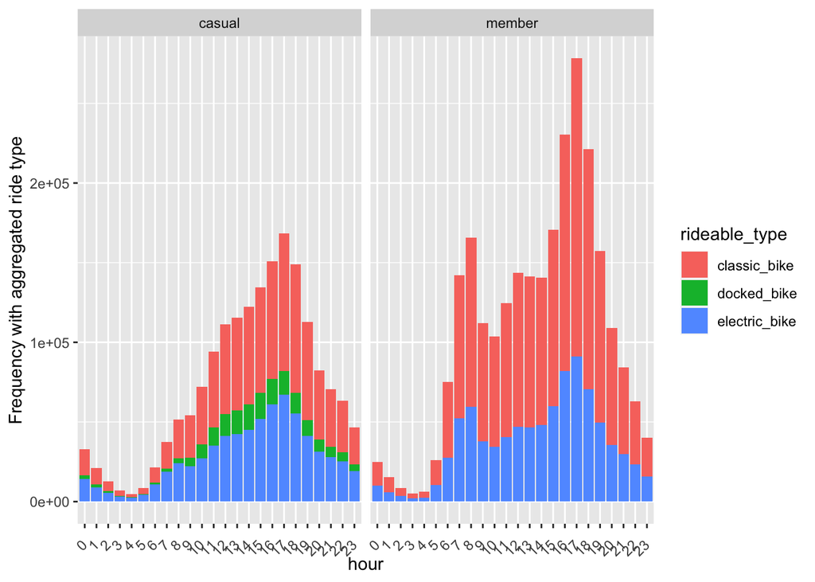

```r
temp <- prepared_all %>% mutate(hour = as.character(hour(started_at)))
options(dplyr.summarise.inform = FALSE)
# set up factor and level to plot bar from 0 to 23.
temp$hour <- factor(temp$hour, levels = c("0","1","2","3","4","5","6","7","8","9","10","11","12","13","14","15","16","17","18","19","20","21","22","23"))
temp %>% ggplot(aes(x = hour, group = rideable_type, fill = rideable_type)) +
  geom_bar()+
  theme(axis.text.x = element_text(angle=45, vjust=.5, hjust=1))+
  facet_wrap(~member_casual)+
  labs(x = "hour",
       y = "Frequency with aggregated ride type")
```

```r
rm(temp)
```

- Average riding time(s) per hour grouped by user type: casual or member

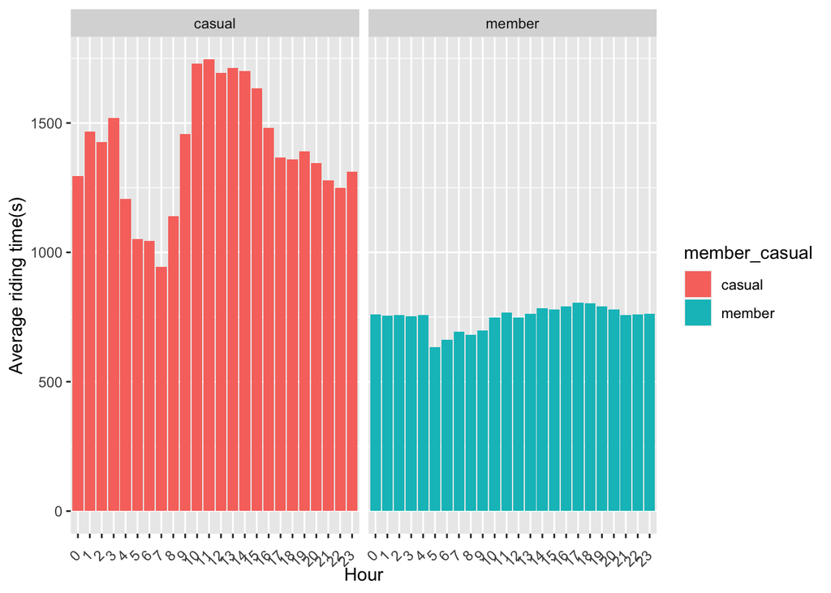

```r
temp <- prepared_all %>% mutate(hour = as.character(hour(started_at)))
temp1 <- temp %>%
  group_by(hour, member_casual) %>%
  summarize(mlen = mean(ride_length))
temp1$hour <- factor(temp1$hour, levels = c("0","1","2","3","4","5","6","7","8","9","10","11","12","13","14","15","16","17","18","19","20","21","22","23"))
temp1 %>% ggplot(aes(x = hour, y = mlen, fill = member_casual)) +
  geom_bar(stat = 'identity')+
  theme(axis.text.x = element_text(angle=45, vjust=.5, hjust=1))+
  facet_wrap(~member_casual)+
  labs(x = "Hour",
       y = "Average riding time(s)")
```

```r
rm(temp)
rm(temp1)
```

- Average riding distance per hour grouped by user type: casual or member

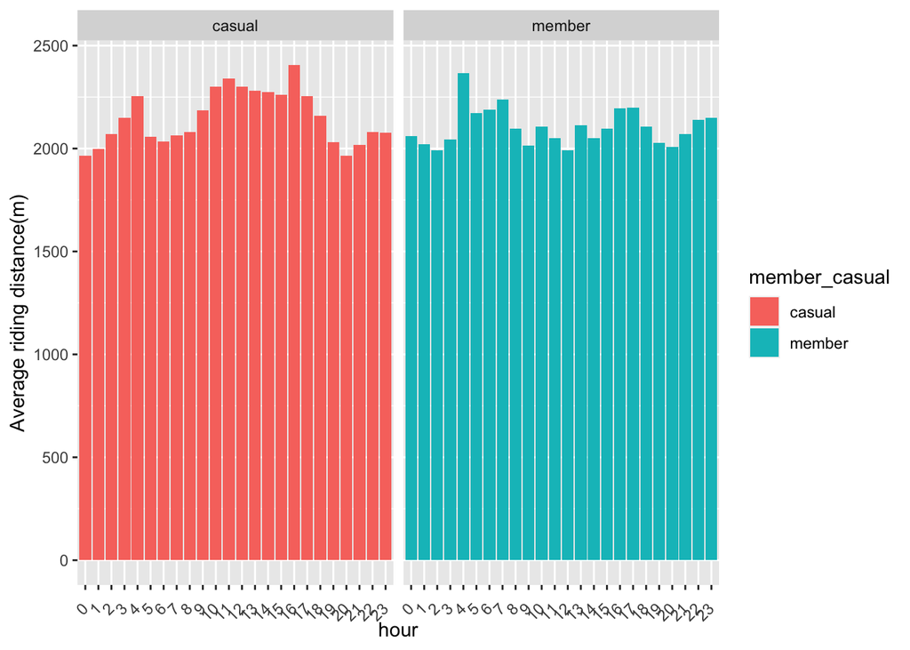

```r
temp <- prepared_all %>% mutate(hour = as.character(hour(started_at)))
temp1 <- temp %>%
  group_by(hour, member_casual) %>%
  summarize(mlen = mean(distance))
temp1$hour <- factor(temp1$hour, levels = c("0","1","2","3","4","5","6","7","8","9","10","11","12","13","14","15","16","17","18","19","20","21","22","23"))
temp1 %>% ggplot(aes(x = hour, y = mlen, fill = member_casual)) +
  geom_bar(stat = 'identity')+
  theme(axis.text.x = element_text(angle=45, vjust=.5, hjust=1))+
  facet_wrap(~member_casual)+
  labs(x = "hour",
       y = "Average riding distance(m)")
```

```r
rm(temp)
rm(temp1)
```

> Finding 12: For the two groups of users, from 6:00 in the morning, the frequency of using shared bicycles gradually increases until it reaches the peak at 17:00 in the afternoon.

> Finding 13: Between 7 am and 9 am, for annual members, the usage of shared bicycles reaches a small peak as well. This pattern is not found among casual users.

### Share and Act: A clear statement of the business task + recommendations based on your analysis

#### Reviewing business task/gut feelings and summerize our findings against analytic results

Before we offer any recommendation, let’s review the business tasks, our ideas/gut feelings at the very beginning and the findings after data analysis.

> There is another finding we don’t know the reason: The average distance traveled on Wednesday is slightly higher than on other weekdays for all riders. That might be caused by some special events in Chicago.

#### Recommendations based on your analysis

- For existing casual users, it is very worth to encourag them to use shared bikes to go to and get off the work. Meanwhile, providing membership experience for them who use shared bicycles for going to or getting off work on consecutive working days is a very good way for promotion and conversion.
- Put more dockless bikes to the market so that casual users can reduce the frequency of using docked bicycles; at the same time, reducing the average cost of using docked bicycles to offset the additional costs of casual users is another good approach for promotion and conversion.
- Increasing the intensity of placing advertisements in restaurants and entertainment venues near the workplaces to expose more brand and utilities of shared bikes is also a good way to for promotion and conversion to casual users.